# Practical Machine Learning Course Project

Alexander Cherkashin

Wednesday, June 10, 2015

## Summary

In this project we’ll build a classification model for predicting how well weight lifting exercise was performed. The data for this project come from this source: http://groupware.les.inf.puc-rio.br/har (see the section on the Weight Lifting Exercise Dataset). This dataset includes measurements from accelerometers on the belt, forearm, arm, and dumbell of 6 participants along with the evaluation how well the exercise was performed (participants were asked to perform barbell lifts correctly and incorrectly in 5 different ways).

## Some exploratory data analysis and data preparation

First of all let’s load the data and have a look on it:

```r
training <- read.csv("./data/pml-training.csv")
testing <- read.csv("./data/pml-testing.csv")
dim(training)
```

```
## [1] 19622   160
```

Dataset has 19622 observation and 160 variables in it.

Let’s look for any columns with `NA`’s:

```r
NAcolumns <- names(training)[sapply(training, anyNA)]
sapply(training[, NAcolumns], function(col) {sum(is.na(col))})
```

```
##            max_roll_belt           max_picth_belt            min_roll_belt
##                    19216                    19216                    19216
##           min_pitch_belt      amplitude_roll_belt     amplitude_pitch_belt
##                    19216                    19216                    19216
##     var_total_accel_belt            avg_roll_belt         stddev_roll_belt
##                    19216                    19216                    19216
##            var_roll_belt           avg_pitch_belt        stddev_pitch_belt
##                    19216                    19216                    19216
##           var_pitch_belt             avg_yaw_belt          stddev_yaw_belt
##                    19216                    19216                    19216
##             var_yaw_belt            var_accel_arm             avg_roll_arm
##                    19216                    19216                    19216
##          stddev_roll_arm             var_roll_arm            avg_pitch_arm
##                    19216                    19216                    19216
##         stddev_pitch_arm            var_pitch_arm              avg_yaw_arm
##                    19216                    19216                    19216
##           stddev_yaw_arm              var_yaw_arm             max_roll_arm
##                    19216                    19216                    19216
##            max_picth_arm              max_yaw_arm             min_roll_arm
##                    19216                    19216                    19216
##            min_pitch_arm              min_yaw_arm       amplitude_roll_arm
##                    19216                    19216                    19216
##      amplitude_pitch_arm        amplitude_yaw_arm        max_roll_dumbbell
##                    19216                    19216                    19216
##       max_picth_dumbbell        min_roll_dumbbell       min_pitch_dumbbell
##                    19216                    19216                    19216
##  amplitude_roll_dumbbell amplitude_pitch_dumbbell       var_accel_dumbbell
##                    19216                    19216                    19216
##        avg_roll_dumbbell     stddev_roll_dumbbell        var_roll_dumbbell
##                    19216                    19216                    19216
##       avg_pitch_dumbbell    stddev_pitch_dumbbell       var_pitch_dumbbell
##                    19216                    19216                    19216
##         avg_yaw_dumbbell      stddev_yaw_dumbbell         var_yaw_dumbbell
##                    19216                    19216                    19216
##         max_roll_forearm        max_picth_forearm         min_roll_forearm
##                    19216                    19216                    19216
##        min_pitch_forearm   amplitude_roll_forearm  amplitude_pitch_forearm
##                    19216                    19216                    19216
##        var_accel_forearm         avg_roll_forearm      stddev_roll_forearm
##                    19216                    19216                    19216
##         var_roll_forearm        avg_pitch_forearm     stddev_pitch_forearm
##                    19216                    19216                    19216
##        var_pitch_forearm          avg_yaw_forearm       stddev_yaw_forearm
##                    19216                    19216                    19216
##          var_yaw_forearm
##                    19216
```

It appears that we have some variables with `NA` value for the most of observations. Futhermore, the `NA` count among them is the same. Also, it is a count of `no` values in `new_window` variable: `sum(training$new_window=="no")` = 19216.

It appears that `new_window` variable indicates some cases with additional measurments. In our set there are very few obesvations with such additional measurements so we’ll filter these columns out along with `new_winow` both from training and testing datasets:

```r
training <- training[training$new_window=="no",!names(training) %in% c("new_window", NAcolumns)]
testing <- testing[testing$new_window=="no",!names(testing) %in% c("new_window", NAcolumns)]
```

THere are also near zero variability vars:

```r
library(caret)
NZcolumns <- nearZeroVar(training)
NZcolumns
```

```
##  [1] 11 12 13 14 15 16 17 18 19 42 43 44 45 46 47 51 52 53 54 55 56 57 58
## [24] 59 73 74 75 76 77 78 79 80 81
```

If you look at `summary(training[,nearZeroVar(training)])` you will see that all these columns are empty. Looks like this values are `NA` too. Filter them out:

```r
training <- training[,-NZcolumns]
testing <- testing[,-NZcolumns]
```

Going further there is a column with subject names: `user_name`. We do not need it because we do not want our model to be subject specific. There is a column `X`, it appears that it contains monotonically increasing integer by 1 every row, starting from 1. It is something like counter of observations. We should filter it out to prevent model overfitting by counter. Also there are time related columns. Model shouldn’t be time specific so we’ll filter such columns too.

Also in the testing set there is one more observation count: `problem_id`. We do not need it right now. Let’s clean datasets from those columns:

```r
library(dplyr)
training <- select(training, -(X:cvtd_timestamp))
testing <- select(testing, -problem_id, -(X:cvtd_timestamp))
```

Nor sure what `num_window` variable is. It name sounds like some counter. Let’s plot it against `classe`:

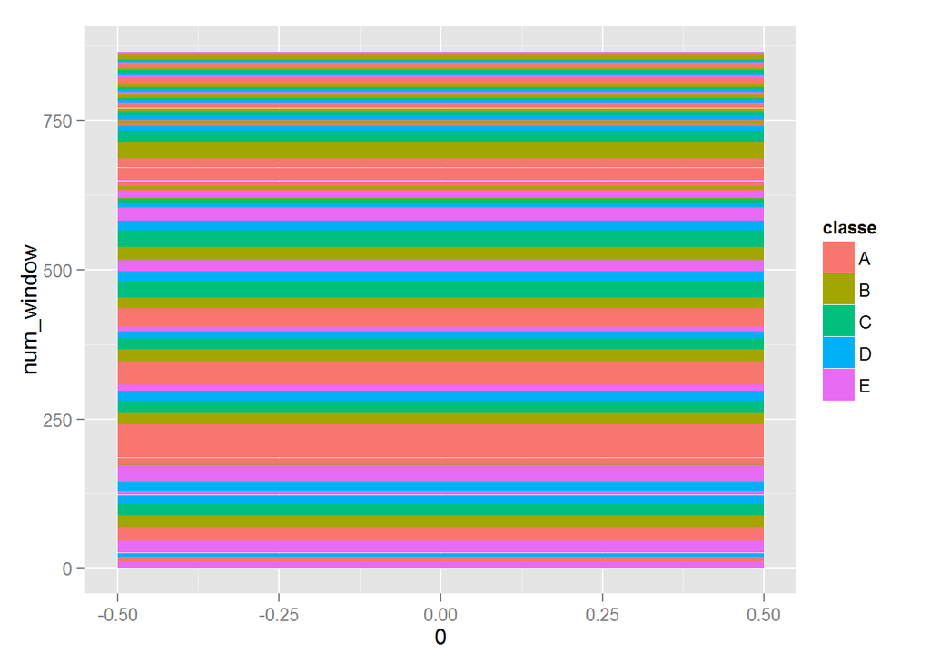

```r
qplot(x=0, num_window, data=training, fill=classe, geom="tile")
```

Indeed, looks like there are some chunks with same `classe` in this variable. To prevent overfitting we’ll filter it out too.

```r
training <- select(training, -num_window)
testing <- select(testing, -num_window)
```

## Some notes about highly correlated predictors

In the training dataset there are some highly correlated variables:

```r
library(tidyr)
c <- data.frame(cor(select(training, -classe)))
c[!upper.tri(c)]<-NA
c$var1=row.names(c)
c <- gather(c, var2, cor, -var1)
c <- na.omit(c)
c <- c[abs(c$cor)>.7,]
c
```

```
##                      var1              var2        cor
## 105             roll_belt          yaw_belt  0.8153069
## 157             roll_belt  total_accel_belt  0.9809159
## 159              yaw_belt  total_accel_belt  0.7621550
## 366            pitch_belt      accel_belt_x -0.9658189
## 367              yaw_belt      accel_belt_x  0.7081443
## 417             roll_belt      accel_belt_y  0.9250067
## 420      total_accel_belt      accel_belt_y  0.9278914
## 469             roll_belt      accel_belt_z -0.9920213
## 471              yaw_belt      accel_belt_z -0.7765868
## 472      total_accel_belt      accel_belt_z -0.9749058
## 477          accel_belt_y      accel_belt_z -0.9334368
## 522            pitch_belt     magnet_belt_x -0.8836627
## 523              yaw_belt     magnet_belt_x  0.7361601
## 528          accel_belt_x     magnet_belt_x  0.8915610
```

[output cut: 25 more lines]

For an example there are 39 cases of correlation more then 0.7.

It doesn’t bad to have them in dataset for prediction purposes with random forest model. Each tree will take only a small random number of variables to select the best one for each split. But it could be bad for feature impotency evaluation (you can read about this issue here: http://blog.datadive.net/selecting-good-features-part-iii-random-forests/ , http://link.springer.com/article/10.1186%2F1471-2105-8-25).

The goal of this project is to make good prediction model so we’ll leave all correlated variables.

## Model building and cross-validation

we’ll try to build random forest model and perform cross-validation all by `train` function from `caret` package. The cross-validation will be performed by bootstrap.632 method 10 times.

want to admit that using random forest usually there is no need in cross-validation because the algorithm itself use bootstrap sampling and produce out of the bag (OOB) error measurment that has been proven to be a good estimation of out of sample error.

Additionally, we’ll set apart 20% of observations for validation dataset and train model on other 80%. After all we’ll check out of sample error rate estimates produes by OOB, bootstrap and validation set.

We will use default `mtry` parameter for `randomForest` model equal to `floor(sqrt(ncol(x)))`.

```r
library(doParallel)
cl <- makeCluster(detectCores())
registerDoParallel(cl)
set.seed(123)

inValidation <- createDataPartition(training$classe, p=.2, list=F)
validation <- training[inValidation,]
training <- training[-inValidation,]
fitControl <- trainControl(method = "boot632", number=10)

forest <- train(classe ~ ., data=training, method="rf", trControl = fitControl, tuneGrid=data.frame(mtry=floor(sqrt(ncol(training)))))
cMatrix <- confusionMatrix(predict(forest, validation), validation$classe)
```

Let’s check out of sample erorr rate estimates:

```r
data.frame(OOB=forest$finalModel$err.rate[500], Bootstrap=1-forest$results[[2]], Validation=1-cMatrix$overall[[1]])
```

```
##           OOB   Bootstrap  Validation
## 1 0.004033832 0.004390999 0.005980239
```

We can see that error rate estimates are very close. But the estimate with validation set is the highest (maybe to some little overfitting) and we choose this *estimate of out of sample error rate = 0.0059802*.